# Higgs Classification

### What is the LHC?

```
In this lab we are working with LHC particle physics data that contains 100k jets of information recorded by the Large Hadron Collider (LHC). The LHC is the world's largest and highest-energy particle collider and was created by CERN through international collaboration from 1998 to 2008. This device, which lies 175 meters below the surface of the earth near Geneva and covers 27 kilometers in circumference was created in efforts of testing many different theories of particle physics. The collider is equipped with four crossing points with 7 detectors placed around these points, each designed for certain kinds of research, and this device was most notably employed to discover the Higgs Boson particle.
```

### What is the Higgs Boson?

```
The Higgs Boson was a theoretical elementary particle of the Standard Model of particle physics and came out of neccessity following the theory of Higgs field. This quantum field, 'Higg's field', was the the most popular explanation at the time for what gave particles their mass. However, due to wave-particle duality all quantum fields, according to this theory, have an associated fundamental particle the Higgs Boson. Because Higgs Boson is responsible for the mass of particles it was though that is the Higgs Boson did exist its mass could be predicted based on its effects on the properties of other particles. The Higgs Boson is often called the "God Particle" because it is regarded as the final missing piece to the explanation of the Standard Model which helps explain three pivotal phenomenom: electromagetic interactions, strong interactions, and the weak nuclear force.
```

### How the LHC works?

```
The LHC works essentially by firing two particles at each other at speeds close to the speed of light. In its 27km circumference there are lined nearly 9000 superconducting magnets with accelerating structures to boost the energy of the particle it encounters. The strong magnetic fields created by these magnets are used to direct two particles at opposite directions of each other to speed them up for their eventual collision at the other end of the tunnel. More specialized magnets are used closer to the collision point in order to squeeze the particles closer togther to increase the probability of them colliding. With the tiny sizes of the particles the task of having two particles collide is similar to having two needles collide at nearly the speed of light. Expanding on this, the collision of high energy particles can produce jets of elementary particles which are then sectioned off and analyzed.
The idea of proving the Higgs Boson using the LHC was as follows. These scientists were proving the existence of Higgs field and if it was real then after colliding two particles at high speeds then the the higgs fielf should ripple and hopefully shoot off a particle which would then be identified as the Higgs Boson. However, another difficulty with identifying this particle was that the Higgs Boson was calculated to be unstable and disintegrate in a fraction of a second. Thus scientists were tasked with searching for the finger print of the Higgs Boson through decay products it leaves behind.
```

- pt (Pt): Transverse momentum = sqrt((Px)^2 + (Py)^2)
  - This is the component of momentum that is transverse, or perpendicular, to the beam line and this is important because momentum along the beam line can easily be the result of left over particles however the transverse momentum gives a strong description of what happens at the vertex of the beam. Where the z-axis is along the beam line the transverse momentum would be dependent upon px and py which are the momentum perpendicular to the beam line. The supplied equation supports this defintion as it uses the momentum in the x and y axis to determine the total transverse momentum which is the vector sum of the two. This sum is found using Pythagorean's theorem as in the above equation.
- eta (n): Pseudorapidity = -ln(tan(theta/2)) or 1/2ln((mag(P) + Pl)/(mag(P) - Pl))
  - Pseudorapidity is a way of measuring the angle at which secondary particles emerge relative to the longitudinal axis of the collision of two particles. In this case it is the angle with respect to the axis of the colliding beams in the LHC and is 0 for angles perpendicular to the collision. Expressed above are two equivalent ways of finding pseudorapidity either by taking the angle of the secondary particle or the momentum of the particle
- phi (phi): Azimuthal angle = cos^-1(x/r)
  - The azimuthal angle is the horizontal angle from the origin to the point of interest. For example if a disk is in the xy plane its aximuthal angle is along the z axis. In the supplied equation we wil be treating the azimuthal angle with respect to the x and y plane which rotates along the z-axis.
- mass (m): Invariant mass = E^2 = P^2 + m^2
  - Invariant mass is the total mass of a system that is independent of the motion of the system. More specifically, it is the total mass that stays the same through all frames of reference.
- ee2 (e2): 2-point ECF ratio
  - Energy correlation functions can be used to probe jet substructures and are based on the energies and pair-wise angles of particles within these jets. 2-point ECF ratio is used for quark/gluon discrimination and is known as 2-point correlators.
- ee3 (e3): 3-point ECF ratio
  - ECF is the same as described above and 3-point ECF is in reference to 3-point correlators. These correlators are best used for boosted W/Z/Higgs boson identification.
- d2 (D2): 3-to-2 point ECF ratio = e3 / (e2)^3
  - An interesting detail to note about the supplied equation is that it gives the ratio of e3 to e2 to the power of 3. Thus it is dependent on our results of 3-point ECF ratio as well as 2-point ECF ratio.
- angularity:
  - angularity is the orientation of one feature to another at a given reference angle
- t1 (tau1): 1-subjettiness
  - N-subjettiness sums the angular distances of N jet constituents to their nearest subjet axis where N is the subjet axis in a jet. At a higher level subjettiness is used to identify boosted hadronic objects such as top quarks. In this case N = 1.
- t2 (tau2): 2-subjettiness
  - Subjettiness definition maintained from t1. In this case N = 2.
- t3 (tau3): 3-subjettiness
  - Subjettiness definition maintained from t1. In this case N = 2.
- t21 (tau21): 21-subjettiness = t2/t1
  - Subjettiness definition maintained from t1. In this case N = 2. This equation is dependent on our results of 1-subjettiness and 2-subjettiness as it is the ratio of these two.
- t32 (tau32): 32-subjettiness= t3/t2
  - Subjettiness definition maintained from t1. In this case N = 2. This equation is dependent on our results of 2-subjettiness and 3-subjettiness as it is the ratio of these two.
- KtDeltaR (KtDeltaR): Cluster sequence
  - Delta R of two subjets within the large-R jet

## 1) Download the datasets (signal & background)

```python
# import library
import pickle
%matplotlib inline
import numpy as np
import matplotlib.pyplot as plt
from scipy import stats
import statistics as st
plt.rcParams["figure.figsize"] = (10,10)

# open the file of interest, and use pickle loading
infile = open ("lab5/qcd_100000_pt_250_500.pkl",'rb') # signal dataset
qcd = pickle.load(infile)
infile = open ("lab5/higgs_100000_pt_250_500.pkl",'rb') # background dataset
higgs = pickle.load(infile)

# list all keys of the files
print(qcd.keys())
print(higgs.keys())
print(len(qcd))
```

```
Index(['pt', 'eta', 'phi', 'mass', 'ee2', 'ee3', 'd2', 'angularity', 't1',
       't2', 't3', 't21', 't32', 'KtDeltaR'],
      dtype='object')
Index(['pt', 'eta', 'phi', 'mass', 'ee2', 'ee3', 'd2', 'angularity', 't1',
       't2', 't3', 't21', 't32', 'KtDeltaR'],
      dtype='object')
100000
```

## 2) Explore training data

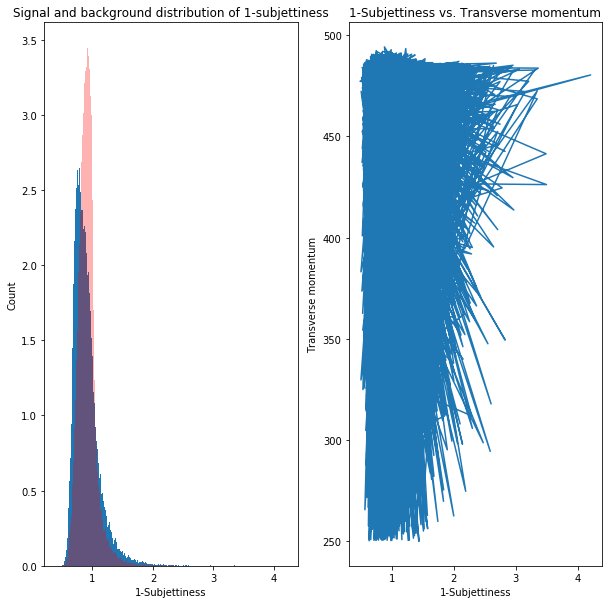

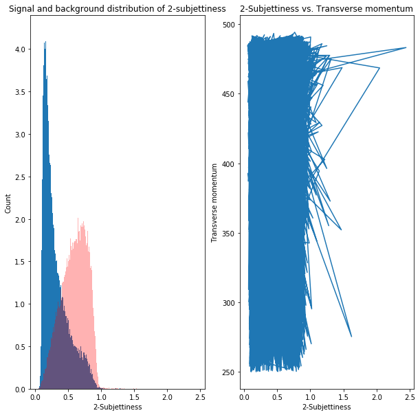

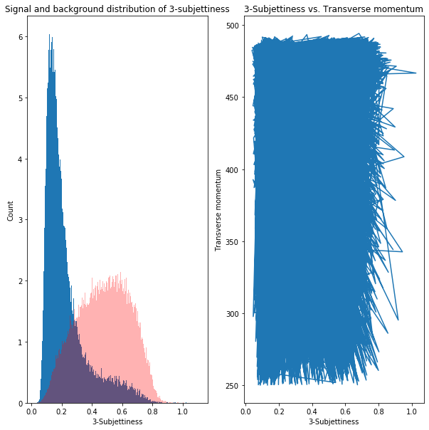

```python
fig, ax = plt.subplots(1, 2)
ax[0].set_title('Signal and background distribution of 1-subjettiness')
ax[0].set_xlabel('1-Subjettiness')
ax[0].set_ylabel('Count')
ax[0].hist(higgs['t1'], 500, histtype = 'bar', density=True)
ax[0].hist(qcd['t1'], 500, histtype = 'bar', color='red', density=True, alpha=0.3)
ax[1].set_xlabel('1-Subjettiness')
ax[1].set_ylabel('Transverse momentum')
ax[1].set_title('1-Subjettiness vs. Transverse momentum')
ax[1].plot(higgs['t1'], higgs['pt'])
plt.show()

fig, ax = plt.subplots(1, 2)
ax[0].set_title('Signal and background distribution of 2-subjettiness')
ax[0].set_xlabel('2-Subjettiness')
ax[0].set_ylabel('Count')
ax[0].hist(higgs['t2'], 500, histtype = 'bar', density=True)
ax[0].hist(qcd['t2'], 500, histtype = 'bar', color='red', density=True, alpha=0.3)
ax[1].set_xlabel('2-Subjettiness')
ax[1].set_ylabel('Transverse momentum')
ax[1].set_title('2-Subjettiness vs. Transverse momentum')
ax[1].plot(higgs['t2'], higgs['pt'])
plt.show()

fig, ax = plt.subplots(1, 2)
ax[0].set_title('Signal and background distribution of 3-subjettiness')
ax[0].set_xlabel('3-Subjettiness')
ax[0].set_ylabel('Count')
ax[0].hist(higgs['t3'], 500, histtype = 'bar', density=True)
ax[0].hist(qcd['t3'], 500, histtype = 'bar', color='red', density=True, alpha=0.3)
ax[1].set_xlabel('3-Subjettiness')
ax[1].set_ylabel('Transverse momentum')
ax[1].set_title('3-Subjettiness vs. Transverse momentum')
ax[1].plot(higgs['t3'], higgs['pt'])
plt.show()
```

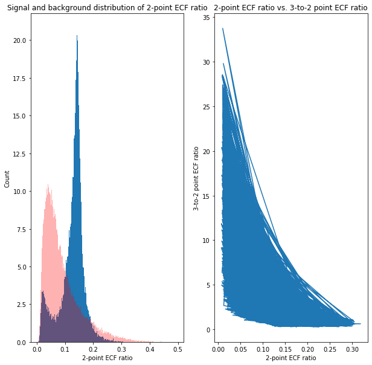

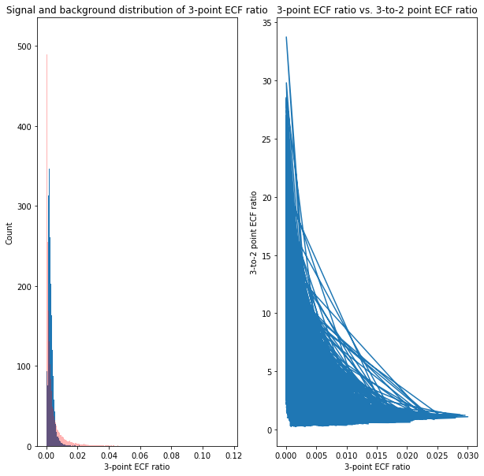

```python
fig, ax = plt.subplots(1, 2)
ax[0].set_title('Signal and background distribution of 2-point ECF ratio')
ax[0].set_xlabel('2-point ECF ratio')
ax[0].set_ylabel('Count')
ax[0].hist(higgs['ee2'], 500, histtype = 'bar', density=True)
ax[0].hist(qcd['ee2'], 500, histtype = 'bar', color='red', density=True, alpha=0.3)
ax[1].set_xlabel('2-point ECF ratio')
ax[1].set_ylabel('3-to-2 point ECF ratio')
ax[1].set_title('2-point ECF ratio vs. 3-to-2 point ECF ratio')
ax[1].plot(higgs['ee2'], higgs['d2'])
plt.show()

fig, ax = plt.subplots(1, 2)
ax[0].set_title('Signal and background distribution of 3-point ECF ratio')
ax[0].set_xlabel('3-point ECF ratio')
ax[0].set_ylabel('Count')
ax[0].hist(higgs['ee3'], 500, histtype = 'bar', density=True)
ax[0].hist(qcd['ee3'], 500, histtype = 'bar', color='red', density=True, alpha=0.3)
ax[1].set_xlabel('3-point ECF ratio')
ax[1].set_ylabel('3-to-2 point ECF ratio')
ax[1].set_title('3-point ECF ratio vs. 3-to-2 point ECF ratio')
ax[1].plot(higgs['ee3'], higgs['d2'])
plt.show()
```

Next I analyzed the signal versus background distribution of 2-point and 3-point ECF ratios and also looked at their respectives graphs compared to 3-to-2 point ECF ratio. AS you can see from the distribution graph the distribution of the background is very different from the signal for 2-point ECF ratio. On the other hand, for 3-point ECF ratio it is similar except that the peak of the background seems to be much higher than the peak of the signal data. I wanted to plot these datasets with respect to 3-to-2 point ECF ratio because I know that 3-to-2 point ECF ratio is dependent on both of the ECF ratios. In the dataset the datais not ordered as it appears in the plots and thus the graph is not giving a totally accurate description of the relationship between 3-to-2 point ECF ratio and 2 or 3-point ECF ratios. For example, these plots appear to decrease exponentially but this is just a result of the data jumping back and forth due to the ordering of the 3-point ECF ratio data. However from this plot we can tell that their is a relationship between 2-point and 3-point ECF ratios because they are displaying and plotting a similar graph shape. Additionally, we can make the general assumption that 3-to-2-point ECF ratios decrease as either 3-point-ecf ratio or 2-point-ratio increases.

In the following plots I have plotted the remaining features making sure to include both the background and signal distributions of each. Pictured in blue is the signal and in red is the background.

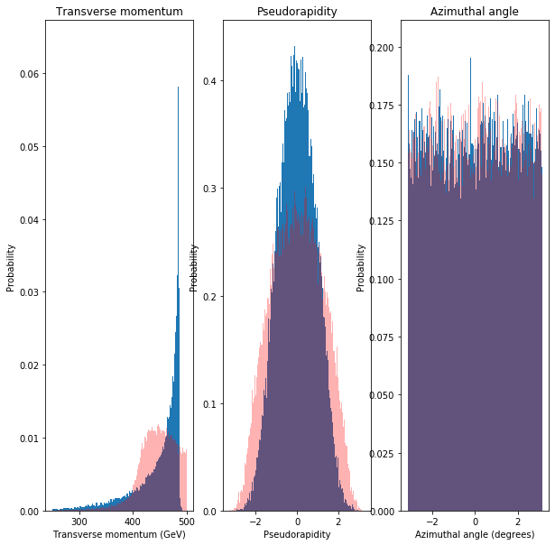

```python
fig, ax = plt.subplots(1, 3)
ax[0].set_title('Transverse momentum')
ax[0].set_xlabel('Transverse momentum (GeV)')
ax[0].set_ylabel('Probability')
ax[0].hist(higgs['pt'], 500, histtype = 'bar', density=True)
ax[0].hist(qcd['pt'], 500, histtype = 'bar', color='red', density=True, alpha=0.3)
ax[1].set_title('Pseudorapidity')
ax[1].set_xlabel('Pseudorapidity')
ax[1].set_ylabel('Probability')
ax[1].hist(higgs['eta'], 500, histtype = 'bar', density=True)
ax[1].hist(qcd['eta'], 500, histtype = 'bar', color='red', density=True, alpha=0.3)
ax[2].set_title('Azimuthal angle')
ax[2].set_xlabel('Azimuthal angle (degrees)')
ax[2].set_ylabel('Probability')
ax[2].hist(higgs['phi'], 500, histtype = 'bar', density=True)
ax[2].hist(qcd['phi'], 500, histtype = 'bar', color='red', density=True, alpha=0.3)
plt.show()
```

- Transverse momentum
  - From the distributions of transverse momentum we can see that both background and the signal dataset are generally left skewed. The range of both distributions are similar ranging from 250-500 and what is interesting to notice is that the background distribution appears to be more Gaussian than the signal distribution.
- Pseudorapidity
  - Both the signal and background distribution are Gaussian the only difference being that the signal distribution reaches a higher peak probability of around .4 which may imply that its dataset is more closely placed towards the average or it has a lower standard deviation. This dataset implies that the average pseudorapidity is an angle is 0 which makes sense because that is the value that is yielded when the angle relative to the beam axis is perpendicular.
- Azimuthal angle
  - The distribution of both the signal and background dataset are very similar and are randomly distributed from around -3 to 3 degrees. This makes sense because the azimuthal angle is the angle from the origin to point of interest and when particles collide in the LHC you can expect random scattering of particles.

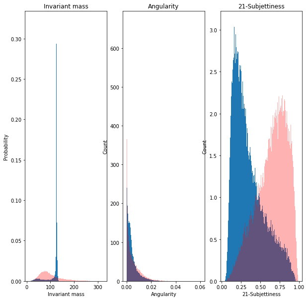

```python
fig, ax = plt.subplots(1, 3)
ax[0].set_title('Invariant mass')
ax[0].set_xlabel('Invariant mass')
ax[0].set_ylabel('Probability')
ax[0].hist(higgs['mass'], 500, histtype = 'bar', density=True)
ax[0].hist(qcd['mass'], 500, histtype = 'bar', color='red', density=True, alpha=0.3)
ax[1].set_title('Angularity')
ax[1].set_xlabel('Angularity')
ax[1].set_ylabel('Count')
ax[1].hist(higgs['angularity'], 500, histtype = 'bar', density=True)
ax[1].hist(qcd['angularity'], 500, histtype = 'bar', color='red', density=True, alpha=0.3)
ax[2].set_title('21-Subjettiness')
ax[2].set_xlabel('21-Subjettiness')
ax[2].set_ylabel('Count')
ax[2].hist(higgs['t21'], 500, histtype = 'bar', density=True)
ax[2].hist(qcd['t21'], 500, histtype = 'bar', color='red', density=True, alpha=0.3)
plt.show()
```

- Invariant mass
  - For this dataset the background and signal distribution vary wildly. The singal distribution is left skewed and peaks very high at around 125. On the other hand, the background distribution is almost Gaussian but looks like a Poisson distribution. It is much more evenly spread out than it is in the signal dataset.
- Angularity
  - Both signal and background distributions of angularity are very similar the only difference being that the background distribution has a higher peak and decreases at a slower rate than the signal distribution.
- 21-subjettiness
  - Interestingly the signal distribution background distribution skew in opposite ways in this case. They seem to be similar in shape besides that except that the signal distribution reaches a higher peak. Another thing to note is that it skews opposite of 32-subjettiness.

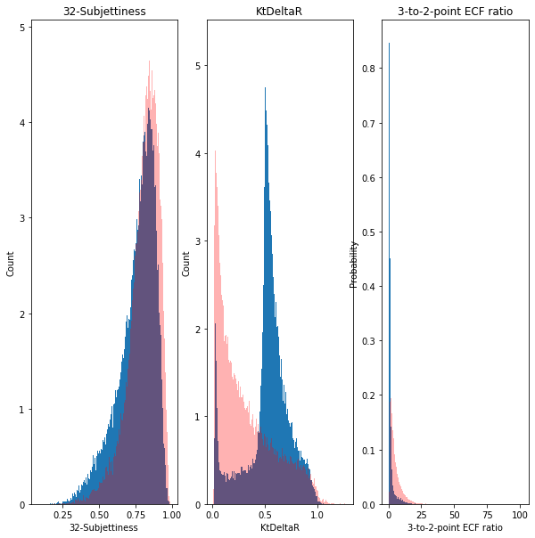

```python
fig, ax = plt.subplots(1, 3)
ax[0].set_title('32-Subjettiness')
ax[0].set_xlabel('32-Subjettiness')
ax[0].set_ylabel('Count')
ax[0].hist(higgs['t32'], 500, histtype = 'bar', density=True)
ax[0].hist(qcd['t32'], 500, histtype = 'bar', color='red', density=True, alpha=0.3)
ax[1].set_title('KtDeltaR')
ax[1].set_xlabel('KtDeltaR')
ax[1].set_ylabel('Count')
ax[1].hist(higgs['KtDeltaR'], 500, histtype = 'bar', density=True)
ax[1].hist(qcd['KtDeltaR'], 500, histtype = 'bar', color='red', density=True, alpha=0.3)
ax[2].set_title('3-to-2-point ECF ratio')
ax[2].set_xlabel('3-to-2-point ECF ratio')
ax[2].set_ylabel('Probability')
ax[2].hist(higgs['d2'], 500, histtype = 'bar', density=True)
ax[2].hist(qcd['d2'], 500, histtype = 'bar', color='red', density=True, alpha=0.3)
plt.show()
```

- 32-subjettiness
  - Both background and signal distribution skew left and are very similarly shaped although the background distribution has just a slightly higher peak. Again its important to note this is opposite of 21-subjettiness.
- KtDeltaR
  - The signal distribution shoots up from around 0.0-0.05 and then has a POisson distribution towards the middle of the distribution. On the other hand, the background distribution is right skewed and is very different from the signal.
- 3-to-2-point ECF ratio
  - Both signal and background ditributions skew right and drop off very quickly. However, the signal dataset drops off more quickly than the background dataset.